# The Markov playlister

Calculating transition probabilities from sequences of album tracks

```r
S = sample(c('loud', 'medium', 'quiet'), replace = T, 10); S
```

1. 'medium'

2. 'quiet'

3. 'medium'

4. 'medium'

5. 'quiet'

6. 'loud'

7. 'loud'

8. 'medium'

9. 'loud'

10. 'quiet'

```r
A = markovchainFit(data = S)$estimate@transitionMatrix; A
```

A matrix: 3 × 3 of type dbl

|  | loud | medium | quiet |
| --- | --- | --- | --- |
| loud | 0.3333333 | 0.3333333 | 0.3333333 |
| medium | 0.2500000 | 0.2500000 | 0.5000000 |
| quiet | 0.5000000 | 0.5000000 | 0.0000000 |

# Playlist evaluator

Given an empirically derived transition matrix, how likely is the sequence below to occur?

```r
#new sequence S'
S_line = c("loud", "loud", "loud",
           "medium", "medium", "loud",
           "medium", "loud", "loud", "medium")

#original, used to derive A
S; S_line
```

1. 'medium'

2. 'quiet'

3. 'medium'

4. 'medium'

5. 'quiet'

6. 'loud'

7. 'loud'

8. 'medium'

9. 'loud'

10. 'quiet'

1. 'loud'

2. 'loud'

3. 'loud'

4. 'medium'

5. 'medium'

6. 'loud'

7. 'medium'

8. 'loud'

9. 'loud'

10. 'medium'

Is it likely that $S'$ was built under our original transition matrix?

We can anwer it by evaluating if $\mathcal{L}(S|A)$ $>$ $\mathcal{L}(S'|A)$

The average Log Likelihood of a playlist $S$, given a playlister $A$, is written as

$$\mathcal{L}(S|A) = \frac{1}{N_S} \sum log\ P[f_{i+1}|f_i]$$

Where $f_i$ represents the discrete feature $f$ of song $i$, and $N_S$ the length of playlist $S$. We take the average because $S$ might have different lengths.

We can also use the same sequence and different playlisters to compare $\mathcal{L}(S|A)$, $\mathcal{L}(S|A')$, $\mathcal{L}(S|A'')$,

which essentially asks "which playlister is more likely to have generated sequence $S$? $A$, $A'$ or $A''$?"

## Implementation

```r
# arr: array com transições; mo: empirically derived markov object, returns log likelihood of arr
ll = function(mo, arr){ t <- log(transitionProbability(mo, arr[1], arr[2]))
                        return( if( length(arr) == 2 ) t else t + ll(mo, arr[2:length(arr)]) )}

# get the mean likelihood of playlist
mll = function(mo, arr){ return (ll(mo, arr)/length(arr)) }
```

# Comparing sequences under the same transition matrix

This shows that our original sequence was most likely built under our empirically derived transition matrix, and also that the new sequence B, was probably built under a different transition matrix.

```r
A <- new("markovchain", states = c("loud", "medium", "quiet"),
     transitionMatrix = matrix(data = as.vector(t(A)),
                               byrow = TRUE, nrow = 3))

A_line <- new("markovchain", states = c("loud", "medium", "quiet"),
          transitionMatrix = matrix(data = c(1/3, 1/3, 1/3,
                                        1/3, 1/3, 1/3,
                                        1/3, 1/3, 1/3),
                               byrow = TRUE, nrow = 3))

#Sequence S is more likely to have occured than S_line
mll(A, S) > mll(A, S_line)

#Sequence S is more likely to have ocurred under A
mll(A, S) > mll(A_line, S)
```

TRUE

TRUE

# Empirical evaluation

Evaluating the same idea on our dataset. First we need to discreticize our features.

```r
dt = fread("novo.csv")

dt %<>% select(!V1) %>%
       group_by(album_id) %>% mutate(album_length = NROW(track_number)) %>%
       filter(track_number < 9) %>%
       select(album_id, track_number, valence, energy, loudness, tempo) %>%
       mutate(valence  = as.factor(rank(valence, na.last = "keep", ties.method = "random")),
              energy   = as.factor(rank(energy, na.last = "keep", ties.method = "random")),
              loudness = as.factor(rank(loudness, na.last = "keep", ties.method = "random")),
              tempo    = as.factor(rank(tempo, na.last = "keep", ties.method = "random"))); dt
```

A grouped_df: 40459 × 6

| album_id <chr> | track_number <int> | valence <fct> | energy <fct> | loudness <fct> | tempo <fct> |
| --- | --- | --- | --- | --- | --- |
| 008M3KxE8IO39sdTRFeZwn | 1 | 1 | 8 | 7 | 6 |
| 008M3KxE8IO39sdTRFeZwn | 2 | 7 | 4 | 3 | 2 |
| 008M3KxE8IO39sdTRFeZwn | 3 | 4 | 2 | 8 | 1 |
| 008M3KxE8IO39sdTRFeZwn | 4 | 2 | 3 | 2 | 4 |
| 008M3KxE8IO39sdTRFeZwn | 5 | 5 | 5 | 4 | 8 |
| 008M3KxE8IO39sdTRFeZwn | 6 | 6 | 7 | 6 | 3 |
| 008M3KxE8IO39sdTRFeZwn | 7 | 3 | 1 | 1 | 7 |
| 008M3KxE8IO39sdTRFeZwn | 8 | 8 | 6 | 5 | 5 |
| 009Y1z4EpUUubSmtf1jEl3 | 1 | 4 | 6 | 1 | 4 |
| 009Y1z4EpUUubSmtf1jEl3 | 2 | 1 | 1 | 2 | 8 |
| 009Y1z4EpUUubSmtf1jEl3 | 3 | 3 | 3 | 4 | 7 |
| 009Y1z4EpUUubSmtf1jEl3 | 4 | 8 | 2 | 6 | 1 |
| 009Y1z4EpUUubSmtf1jEl3 | 5 | 2 | 4 | 5 | 3 |
| 009Y1z4EpUUubSmtf1jEl3 | 6 | 5 | 5 | 3 | 2 |
| 009Y1z4EpUUubSmtf1jEl3 | 7 | 6 | 7 | 8 | 5 |
| 009Y1z4EpUUubSmtf1jEl3 | 8 | 7 | 8 | 7 | 6 |
| 00c7nZRNKDJjp7jdoEfB0Z | 1 | 8 | 7 | 7 | 7 |
| 00c7nZRNKDJjp7jdoEfB0Z | 2 | 3 | 3 | 4 | 8 |
| 00c7nZRNKDJjp7jdoEfB0Z | 3 | 5 | 4 | 3 | 5 |
| 00c7nZRNKDJjp7jdoEfB0Z | 4 | 7 | 8 | 8 | 6 |
| 00c7nZRNKDJjp7jdoEfB0Z | 5 | 1 | 2 | 2 | 2 |
| 00c7nZRNKDJjp7jdoEfB0Z | 6 | 2 | 1 | 1 | 3 |
| 00c7nZRNKDJjp7jdoEfB0Z | 7 | 4 | 5 | 5 | 1 |
| 00c7nZRNKDJjp7jdoEfB0Z | 8 | 6 | 6 | 6 | 4 |
| 00CO8WwZ8YgoSfB2k7ERI4 | 1 | 5 | 6 | 2 | 3 |
| 00CO8WwZ8YgoSfB2k7ERI4 | 2 | 8 | 7 | 8 | 5 |
| 00CO8WwZ8YgoSfB2k7ERI4 | 3 | 7 | 8 | 6 | 8 |
| 00CO8WwZ8YgoSfB2k7ERI4 | 4 | 6 | 2 | 4 | 4 |
| 00CO8WwZ8YgoSfB2k7ERI4 | 5 | 3 | 3 | 3 | 7 |
| 00CO8WwZ8YgoSfB2k7ERI4 | 6 | 2 | 1 | 1 | 6 |
| ⋮ | ⋮ | ⋮ | ⋮ | ⋮ | ⋮ |
| 3Bdtv2Y8lHrXOsboFA96hX | 2 | 3 | 8 | 6 | 7 |
| 3Bdtv2Y8lHrXOsboFA96hX | 3 | 2 | 5 | 3 | 5 |
| 3Bdtv2Y8lHrXOsboFA96hX | 4 | 1 | 4 | 2 | 2 |
| 3Bdtv2Y8lHrXOsboFA96hX | 5 | 7 | 2 | 1 | 1 |
| 3Bdtv2Y8lHrXOsboFA96hX | 6 | 6 | 7 | 5 | 8 |
| 3Bdtv2Y8lHrXOsboFA96hX | 7 | 5 | 3 | 4 | 4 |
| 3Bdtv2Y8lHrXOsboFA96hX | 8 | 8 | 6 | 8 | 6 |
| 6btE9k5ED8ydC8XY1K0kko | 1 | 2 | 5 | 5 | 1 |
| 6btE9k5ED8ydC8XY1K0kko | 2 | 4 | 4 | 2 | 7 |
| 6btE9k5ED8ydC8XY1K0kko | 3 | 7 | 6 | 3 | 6 |
| 6btE9k5ED8ydC8XY1K0kko | 4 | 3 | 7 | 7 | 4 |
| 6btE9k5ED8ydC8XY1K0kko | 5 | 1 | 3 | 4 | 2 |
| 6btE9k5ED8ydC8XY1K0kko | 6 | 5 | 1 | 6 | 3 |
| 6btE9k5ED8ydC8XY1K0kko | 7 | 6 | 2 | 1 | 5 |
| 5EzDhyNZuO7kuaABHwbBKX | 1 | 1 | 1 | 2 | 2 |
| 5EzDhyNZuO7kuaABHwbBKX | 2 | 3 | 3 | 3 | 4 |
| 5EzDhyNZuO7kuaABHwbBKX | 3 | 7 | 4 | 7 | 1 |
| 5EzDhyNZuO7kuaABHwbBKX | 4 | 8 | 8 | 4 | 7 |
| 5EzDhyNZuO7kuaABHwbBKX | 5 | 6 | 2 | 1 | 6 |
| 5EzDhyNZuO7kuaABHwbBKX | 6 | 2 | 5 | 6 | 3 |
| 5EzDhyNZuO7kuaABHwbBKX | 7 | 5 | 7 | 8 | 5 |
| 5EzDhyNZuO7kuaABHwbBKX | 8 | 4 | 6 | 5 | 8 |
| 6YKk4wlKdACRITGKmGnoIm | 1 | 1 | 1 | 2 | 2 |
| 6YKk4wlKdACRITGKmGnoIm | 2 | 3 | 3 | 4 | 4 |
| 6YKk4wlKdACRITGKmGnoIm | 3 | 7 | 4 | 7 | 1 |
| 6YKk4wlKdACRITGKmGnoIm | 4 | 8 | 8 | 3 | 7 |
| 6YKk4wlKdACRITGKmGnoIm | 5 | 6 | 2 | 1 | 6 |
| 6YKk4wlKdACRITGKmGnoIm | 6 | 2 | 5 | 6 | 3 |
| 6YKk4wlKdACRITGKmGnoIm | 7 | 5 | 7 | 8 | 5 |
| 6YKk4wlKdACRITGKmGnoIm | 8 | 4 | 6 | 5 | 8 |

# Fitting the Markov Chain

First we separating between training and test.

```r
dt = split(dt, dt$album_id)
size <- floor(0.75 * length(dt))

train_ind <- sample(seq_len(length(dt)), size = size)

dt_train <- dt[train_ind]
dt_test <- dt[-train_ind]
```

## Calculating transition matrices

As control, I randomly shuffled the tracks of each album and calculated a transition matrix from both the randomized and original versions. This would give me a different playlister $A'$ to compare with our empirically derived transition matrix.

# Results

```r
teste
```

A data.frame: 8 × 4

| feature <chr> | condition <chr> | log_likelihood <dbl> | se <dbl> |
| --- | --- | --- | --- |
| energy | empirical | -1.741490 | 0.0008059214 |
| energy | random | -1.741266 | 0.0007712063 |
| loudness | empirical | -1.739663 | 0.0008532490 |
| loudness | random | -1.740837 | 0.0007345395 |
| tempo | empirical | -1.740950 | 0.0007829605 |
| tempo | random | -1.741300 | 0.0007560253 |
| valence | empirical | -1.739728 | 0.0007837072 |
| valence | random | -1.740857 | 0.0007109333 |

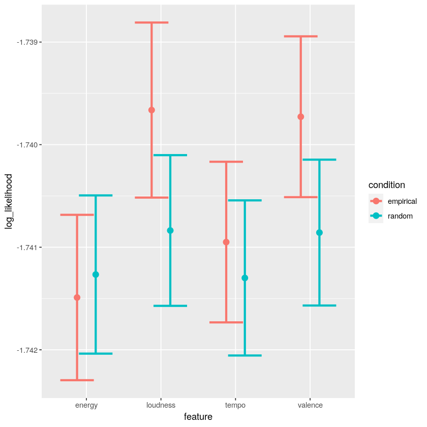

```r
ggplot(teste, aes(x=feature, y=log_likelihood, color = condition)) +
  geom_errorbar(size = 1.2, aes(ymin=log_likelihood-se, ymax=log_likelihood+se), position=position_dodge(0.5)) +
  geom_point(size = 3, position=position_dodge(0.5), fill = 'black')
```

## Final analysis

Should we start from the top?

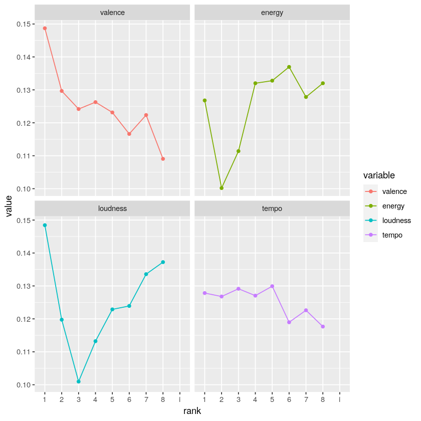

```r
ggplot(data=probmatrix, aes(x=rank, y=value, group = 1)) +
  facet_wrap(~variable)+ geom_line(aes(color=variable, na.rm = TRUE))+
  geom_point(aes(color=variable), na.rm = TRUE)
```

[output not shown]

[figure not shown]

```r
dt_test
```

[output not shown]

## References

McFee, B., & Lanckriet, G. R. (2011, October). The Natural Language of Playlists. In ISMIR (Vol. 11, pp. 537-541).